# Appendix - Selection against instability: stable subgraphs are most frequent in empirical food webs

Jonathan J. Borrelli

Wednesday, July 23, 2014

[The code provided here can also be obtained from GitHub by clicking this link](https://github.com/jjborrelli/Subgraph-Stability)

# 1 Definitions

## 1.1 Subgraph Library

The following code defines the sign matrix for each of the thirteen possible three-node subgraphs. Here, the “s” in the object name indicates that only single links are used, while a “d” indicates the presence of double links.

```r
s1<-matrix(c(0,1,0,-1,0,1,0,-1,0),nrow=3,ncol=3)
s2<-matrix(c(0,1,1,-1,0,1,-1,-1,0),nrow=3,ncol=3)
s3<-matrix(c(0,1,-1,-1,0,1,1,-1,0),nrow=3,ncol=3)
s4<-matrix(c(0,1,1,-1,0,0,-1,0,0),nrow=3,ncol=3)
s5<-matrix(c(0,0,1,0,0,1,-1,-1,0),nrow=3,ncol=3)

d1<-matrix(c(0,1,1,-1,0,1,-1,1,0),nrow=3,ncol=3)
d2<-matrix(c(0,1,1,1,0,1,-1,-1,0),nrow=3,ncol=3)
d3<-matrix(c(0,1,-1,1,0,0,1,0,0),nrow=3,ncol=3)
d4<-matrix(c(0,1,1,-1,0,0,1,0,0),nrow=3,ncol=3)
d5<-matrix(c(0,1,1,-1,0,1,1,-1,0),nrow=3,ncol=3)
d6<-matrix(c(0,1,1,1,0,1,1,1,0),nrow=3,ncol=3)
d7<-matrix(c(0,1,1,1,0,1,1,-1,0),nrow=3,ncol=3)
d8<-matrix(c(0,1,1,1,0,0,1,0,0),nrow=3,ncol=3)

mot.lst <- list(s1, s2, s3, s4, s5, d1, d2, d3, d4, d5, d6, d7, d8)
names(mot.lst) <- c("s1", "s2", "s3", "s4", "s5", "d1", "d2", "d3", "d4", "d5", "d6", "d7", "d8")
```

## 1.2 Define required functions

### 1.2.1 Functions for counting motifs

The `motif_counter` function takes in a list of graph objects and applies `triad.census` to each. It returns a data frame of the frequency of each connected three-node digraph.

```r
motif_counter <- function(graph.lists){
  require(igraph)

  if(!is.list(graph.lists)){
    stop("The input should be a list of graph objects")
  }

  triad.count <- lapply(graph.lists, triad.census)
  triad.matrix <- matrix(unlist(triad.count), nrow = length(graph.lists), ncol = 16, byrow = T)
  colnames(triad.matrix) <- c("empty", "single", "mutual", "s5", "s4", "s1", "d4",
                              "d3", "s2", "s3","d8", "d2", "d1", "d5", "d7", "d6")

  triad.df <- as.data.frame(triad.matrix)

  motif.data.frame <- data.frame(s1 = triad.df$s1, s2 = triad.df$s2, s3 = triad.df$s3, s4 = triad.df$s4,
                                 s5 = triad.df$s5, d1 = triad.df$d1, d2 = triad.df$d2, d3 = triad.df$d3, d4 = triad.df$d4,
                                 d5 = triad.df$d5, d6 = triad.df$d6, d7 = triad.df$d7, d8 = triad.df$d8)

  rownames(motif.data.frame) <- names(graph.lists)
  return(motif.data.frame)
}
```

The `permutes_rc` function is a null model that generates `iter` number of permuted matrices from the input matrix (`mat`). Each permuted matrix is created by randomly sampling 2x2 submatrices matching the pattern

```
     [,1] [,2]
[1,]    0    1
[2,]    1    0
```

or

```
     [,1] [,2]
[1,]    1    0
[2,]    0    1
```

and swapping the 0s and 1s. This null model preserves the number of prey and predators of each species (the degree distribution).

```r
permutes_rc <- function(mat, iter = 100){

  pattern1 <- matrix(c(0,1,1,0), nrow = 2, ncol = 2)
  pattern2 <- matrix(c(1,0,0,1), nrow = 2, ncol = 2)
  count <- 0

  mat.list <- list()
  for(i in 1:iter){
    mat.list[[i]] <- matrix(0, nrow = nrow(mat), ncol = ncol(mat))
  }

  while(count < iter){
    srow <- sample(1:nrow(mat), 2)
    scol <- sample(1:ncol(mat), 2)

    test <- mat[srow, scol]

    if(sum(test == pattern1) == 4){
      count <- count + 1
      mat[srow, scol] <- pattern2
      mat.list[[count]] <- mat

      next
    } else if(sum(test == pattern2) == 4){
      count <- count + 1
      mat[srow, scol] <- pattern1
      mat.list[[count]] <- mat

      next
    } else {next}
  }

  matrices <- lapply(mat.list, as.matrix)
  return(permuted.matrices = matrices)
}
```

### 1.2.2 Functions for determining quasi sign-stability

There are two main functions for determining quasi sign-stability, and a third that wraps them together to generate the desired number of iterations.

The function `ran.unif` takes an input of a signed matrix. It will then check each cell to see if there is a 1 or -1. Each 1 will be replaced by a value drawn from the random uniform distribution between 0 and 10, while each -1 is replaced by a value from the random uniform distribution between -1 and 0. The `ran.unif` function also assigns values to the diagonal from a random uniform distribition between -1 and 0. The resulting randomly sample matrix is returned.

```r
ran.unif <- function(motmat){
  newmat <- apply(motmat, c(1,2), function(x){
    if(x==1){runif(1, 0, 10)}else if(x==-1){runif(1, -1, 0)} else{0}
  })
  diag(newmat) <- runif(3, -1, 0)
  return(newmat)
}
```

Given the input matrix `maxRE` will compute the eigenvalues and return the largest real part.

```r
maxRE <- function(rmat){
  lam.max <- max(Re(eigen(rmat)$values))
  return(lam.max)
}
```

The above two functions are combined in `eig.analysis`. Given the number of desired sampling iterations, `n`, and a list of sign matrices to analyze, `matrices`, the `eig.analysis` function will return an `n` by `length(matrices)` matrix of eigenvalues. Specifically it is returning the $max(Re(\lambda))$ for each sampled matrix. From this matrix quasi sign-stability can be calculated as the proportion of values in each column that are negative.

```r
eig.analysis <- function(n, matrices){
  cols <- length(matrices)
  rows <- n
  eigenMATRIX <- matrix(0, nrow = rows, ncol = cols)
  for(i in 1:n){
    ranmat <- lapply(matrices, ran.unif)
    eigs <- sapply(ranmat, maxRE)
    eigenMATRIX[i,] <- eigs
  }
  return(eigenMATRIX)
}
```

# 2 Analysis

Load required packages

```r
library(igraph)
library(ggplot2)
library(reshape2)
```

## 2.1 Determining motif frequency

Load in web data from GitHub. [Click here to download the .Rdata file](https://github.com/jjborrelli/Subgraph-Stability/blob/master/webGRAPHS.Rdata?raw=true). This file is a list of igraph graph objects for each of the 50 webs used in the analysis. Once you have downloaded the file into your working directory:

```r
load(paste(getwd(), "webGRAPHS.Rdata", sep = "/"))
```

The frequencies of each of the different subgraphs can now be determined easily with `motif_counter`.

```r
motfreq <- motif_counter(web.graphs)
kable(motfreq, format = "pandoc")
```

```
                    s1      s2   s3      s4      s5    d1     d2     d3     d4    d5    d6    d7    d8
--------------  ------  ------  ---  ------  ------  ----  -----  -----  -----  ----  ----  ----  ----
akatorea           115      14    0     789    1466     0      0      0      0     0     0     0     0
akatoreb            63      18    0     338     497     0      0      0      0     0     0     0     0
benguela           269     445    0     464     391    19     48      8     24     0     1     1     0
berwick            132      14    0     855    1553     0      0      0      0     0     0     0     0
blackrock          407      71    0    2507    1976     0      0      0      0     0     0     0     0
bridgebrook       1931     629    0    6338    1539    30    111      0     21     0     4     0     0
broad              641      16    0    5087    4151     0      0      0      0     0     0     0     0
broom              527     358    0     275    3292     0      0      0      0     0     0     0     0
bsq               5742    1202    0   10011    5736     0      0      0      0     0     0     0     0
canton             717     116    0    6561    5976     0      0      0      0     0     0     0     0
catlins             59       9    0     186     721     0      0      0      0     0     0     0     0
caymen fw        22330    5965    0   64365   53833     0      0      0      0     0     0     0     0
chesapeake          86      21    0      58     130     0      0      0      0     0     0     0     0
coachella          311     638    0     424     317   103    139     96     91    11    24    39     7
coweeta1            68      36    0     266     551     0      0      0      0     0     0     0     0
coweeta17           86      26    0     421     822     0      0      0      0     0     0     0     0
csm               4540     944    0    5545    5327     0      0      0      0     0     0     0     0
cuban fw         23615    6220    0   65677   56327     0      0      0      0     0     0     0     0
dempstersau        539      28    0    3215    2255     0      0      0      0     0     0     0     0
dempsterssp        723      28    0    4054    4145     0      0      0      0     0     0     0     0
dempsterssu       2464     567    0   10208    8210     0      0      0      0     0     0     0     0
elverde           8571    2824   26   11485   10558   183    179   1170   2668   174    13   112   382
epb              10931    1730    0   16385   11214     0      0      0      0     0     0     0     0
flensburg         1653     571    0    3763    2712     0      0      0      0     0     0     0     0
german             494      87    0    1876    2057     0      0      0      0     0     0     0     0
grass               82      30    0     193     152     0      0      0      0     0     0     0     0
healy             1108     267    0    5119    4929     0      0      0      0     0     0     0     0
jamaican fw      24879    6989    0   73176   61667     0      0      0      0     0     0     0     0
kyeburn            657     213    0    6381    4470     0      0      0      0     0     0     0     0
lilkyeburn         654      35    0    2116    2026     0      0      0      0     0     0     0     0
littlerock       12210    9148    0   39239   11325   383   1039     63   1061    30    40    27    21
martins            498     114    0    1257    2195     0      0      0      0     0     0     0     0
narrowdale          83      27    0     357    1208     0      0      0      0     0     0     0     0
northcol           278      50    0     710    1731     0      0      0      0     0     0     0     0
otago             5920    1950    0   10779    9177   182    211    272    634     0    16    22    36
powder             270      38    0     945    1894     0      0      0      0     0     0     0     0
quick             2990    3059    2    6332    1873   419   1219    297    660    38   123   195    53
reef              1448    1694    9    2001    1103   147    219    147    354    56    17    55    16
shelf             5978   11211    2   11458    7760   130    132     33     79    13     0     4     1
skipwith           330    1169    0    1985     559    54    314      1     45     0    20     0     0
stmarks            617     223    0     442     569     0      0      0      0     0     0     0     0
stmartin           538     278    0     712     482     0      0      0      0     0     0     0     0
stony             1035     124    0    8929    8208     0      0      0      0     0     0     0     0
suttonau           206      16    0    2570    1554     0      0      0      0     0     0     0     0
suttonsp           220       4    0    3467    2067     0      0      0      0     0     0     0     0
suttonsu           312       6    0    6445    1728     0      0      0      0     0     0     0     0
sylt              4489    1654    0    6938    7989    45     67     50     75     0     0     1     2
troy               186      20    0     507     794     0      0      0      0     0     0     0     0
venlaw             186      17    0     638     932     0      0      0      0     0     0     0     0
ythan_nopar96     1247     362    0    1905    2551    13      4     21      8     0     0     0     0
```

The following code runs the null model analysis for the 50 food webs. First, each of the fifty webs are converted into binary adjacency matrices (`web.matrices`). Because the null model is a stochastic process the `set.seed(10)` allows for reproducible results. The code then loops through the list of adjacency matrices, generating 1000 permuted versions. The subgraphs are counted in each permuted matrix, and stored in a list (`p.mot`).

```r
web.matrices <- lapply(web.graphs, get.adjacency, sparse = F)

set.seed(10)
pmot <- list()

for(i in 1:length(web.matrices)){
  p <- permutes_rc(web.matrices[[i]], 1000)
  g <- lapply(p, graph.adjacency)
  pmot[[i]] <- motif_counter(g)
  print(i)
}
```

Once subgraph counts have been obtained, the mean and standard deviation for each subgraph are computed. Z-scores are then computed as described in the methods section:  
$z_i = \frac{x_i - \overline{x}}{\sigma}$ In cases where there were no occurences of a subgraph (standard deviation = 0) `NaN` is produced following the appllication of the above formula. In these cases I have replaced the `NaN` with 0. The normalized profile was then computed (as desribed in the methods):  
$n_i = \frac{z_i}{\sqrt{\sum{z_j^2}}}$

```r
mus <- t(sapply(pmot, function(x){colMeans(x)}))
sig <- t(sapply(pmot, function(x){apply(x, 2, sd)}))
```

```r
z <- (motfreq - mus)/sig
zmat <- as.matrix(z)
zmat[is.nan(zmat)] <- 0
profile <- apply(zmat, 2, function(x){x/sqrt(rowSums(zmat^2))})
```

**Figure 1a** is then just a boxplot of the above object `profile`, reordered according to decreasing quasi sign-stability (see below).

## 2.2 Determining Quasi Sign-Stability

The first step to get quasi sign stability is to get the largest eigenvalues from a series of randomly parameterized sign matrices. In the following code I generate 10000 random parameterizations for each of the 13 subgraphs’s sign matrices (`mot.lst`). The `eig.analysis` function will return a matrix where each column is a different subgraph and each row is the largest eigenvalue of a particular randomization.

```r
set.seed(5)

n <- 10000
mot.stab<- eig.analysis(n, mot.lst)
colnames(mot.stab) <- names(mot.lst)
```

From that matrix, quasi sign-stability is calculated as the proportion of rows with a negative value. In other words, how many random parameterizations of the sign matrix were locally stable?

```r
mot.qss <- apply(mot.stab, 2, function(x){sum(x<0)/n})
sorted <- sort(mot.qss, decreasing = T)
sorted
```

```
    s1     s4     s5     s2     d3     d4     s3     d2     d1     d5
1.0000 1.0000 1.0000 0.5345 0.0891 0.0866 0.0561 0.0428 0.0370 0.0101
    d7     d6     d8
0.0021 0.0000 0.0000
```

### 2.2.1 Correlation

Compute the correlation between QSS and median z-score

```r
med.z <- apply(zmat[,names(sorted)], 2, median)

cor.test(sorted, med.z)
```

```
    Pearson's product-moment correlation

data:  sorted and med.z
t = 3.527, df = 11, p-value = 0.004737
alternative hypothesis: true correlation is not equal to 0
95 percent confidence interval:
 0.2966 0.9130
sample estimates:
   cor
0.7285
```

# 3 Code for the figures

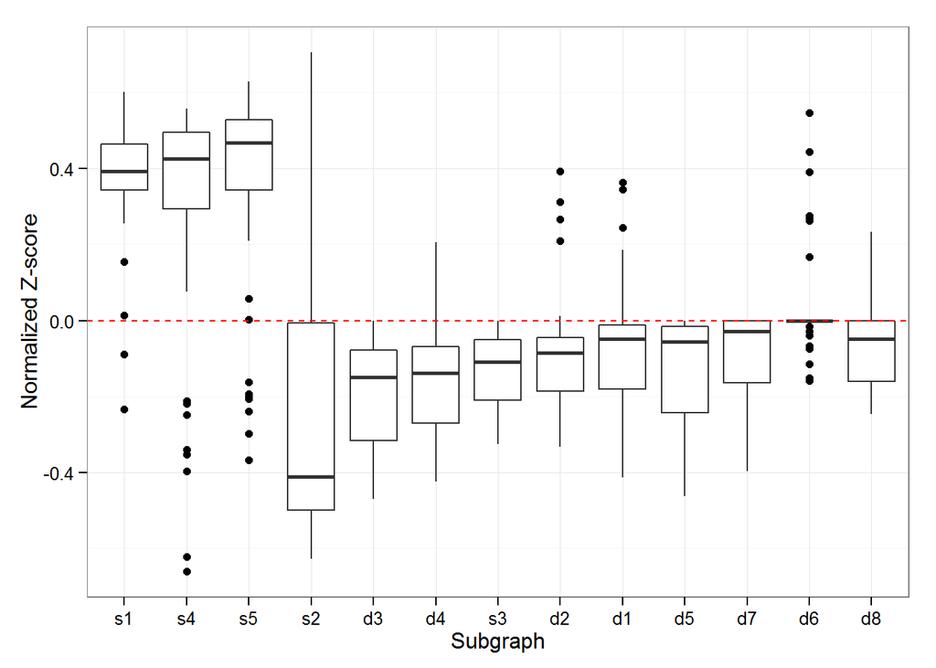

```r
plot.df <- melt(profile[,names(sorted)])

fplot <- ggplot(plot.df, aes(x = Var2, y = value)) + geom_boxplot()
fplot <- fplot + geom_hline(aes(yintercept = 0), lty = 2, col = "red")
fplot <- fplot + theme_bw()
fplot + xlab("Subgraph") + ylab("Normalized Z-score")
```

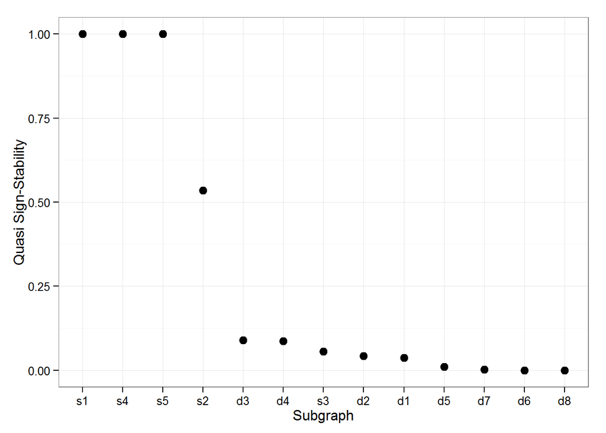

```r
sort.df <- melt(sorted)

qssplot <- ggplot(sort.df, aes(x = 1:13, y = value)) + geom_point(shape = 19, size = 3) + theme_bw()
qssplot + xlab("Subgraph") + ylab("Quasi Sign-Stability") + scale_x_discrete(limits=names(sorted))
```